[figure not shown]

# Capstone Project - Wine Reviews

## *Data Processing and Analysis in Python*

Prof. Sean Barnes

- Group 4: Kevin Anani, Lorenzo Bartolini, Gabrielle Bianchi

# Capstone Project Summary

1.Introduction

2.Processing Tasks

```
* Duplicated Values
* Identifying NAs
* Imputting NAs
* Year Extraction
```

3.Data Exploration

```
* Exploration of points
* Exploration of price
* Exploration of year
```

4.Business Questions

```
* What are the most expensive wines?
* Which countries produce the most wines?
* What is the distribution of prices and points by country?
* For regular consumers, what is distribution of prices and points by country?
* Which provinces are the most bankable?
* Which varieties are the most popular? Most expensive? Best rated?
* Which wine reviewers are the most influencial?
```

5.Understanding the wine descriptions

```
* Is there a relationship between the length of the description and the rating?
* What can we learn from a wordcloud?
```

6.Conclusion

7.References

## 1. Introduction

In 2016, over 800 million gallons of wine were produced in the United States alone, which accounts for only about 12% of the global production. The global production is estimated to be 6.6 billion gallons of wine, or 33 billion regular sized bottles! By its nature, wine suits a large variety of occasions. Whether it is served as an aperitif, subliming a three-course meal or for socializing with friends, wine can be found around all corners. Over the past few years, wine sales have captured a market share of about 17% of total alcohol retail sales in the United States. The average wine consumption went up 25% between 2005 and 2016. Barefoot, America’s #1 table brand, generated about $ 665 millions in sales in 2018.

Our goal is to acquire a deeper understanding of the wine landscape industry in the United States. We aim to acquire a large, unprocessed dataset containing thousands of wine reviews. After a thorough cleaning, we will conduct descriptive analytics and hope to discover some interesting trends and generate some insightful visualizations. From end to end, the project will be developed using Python and the relevant libraries, mainly Numpy, Pandas and Seaborn.

The Winery field is used to store the name of the winery that made that specific wine. The Designation field is the vineyard name within the winery where the grapes are from. The Price field is the cost of one standard bottle of wine. The Taster Name field is used to store the name of the person who tasted then reviewed the wine on the platform. Lastly, the Taster Twitter Handle field is used to store the taster’s twitter handle.

## 2. Processing tasks to prepare data for analysis:

After playing around with the dataset in the preliminary phase of the analysis, we realized that the dataset is far from being processed, unlike the majority of Kaggle datasets. Rather, it seems that the dataset is simply hosted on Kaggle so that it gets a better visibility for anyone interested in diving deeper in the world of wine reviews. A number of processing tasks will be necessary before running any kind of analysis.

The data is fairly dirty. Critical processing tasks such as removing duplicated values and imputting NAs (both categorical and numerical) are necessary, as well as text processing to identify the most common words used to describe wines and extract the year the grapes were harvested, an essential aspect for any wine enthusiast.

#### Processing Tasks Summary

- Duplicated Values
- Identifying NAs
- Imputting NAs
  - region_2
  - designation
  - taster twitter handle
  - taster name
  - region 1
  - price
  - province/country/variety
- Year Extraction

## What we hope to find in the data:

We hope to find some of the most popular wines and classify them by variety. In the descriptive part of our analysis, we hope to visualize wines by country, popularity, blend and ratings. Some of the questions we may answer are:

- What are the top producing wine countries in terms of quantity?
- What are the countries with the highest rated wines, regardless of quantity?
- Where are the most costly wines made?
- Where are the cheapest wines made?
- Word cloud of the most common words used to describe a wine
- Distribution of points and prices by taster’s names (if applicable)?

We will also produce descriptive statistics to better understand and grasp the data, such as the range of the points given to different wines, the mean and median ratings; but also statistics about the experts who graded those wines. Finally, we will take a look at the correlation between the different variables present in the dataset.

# Project Development

```python
import numpy as np
import pandas as pd
import matplotlib.pyplot as plt
import seaborn as sns
```

```python
pd.reset_option('all')
```

[output not shown]

Setting the file path

```python
%pwd
path = 'C:\\Users\\loren\\Desktop\\Py Project\\'
```

### 1. Data Exploration

```python
df = pd.read_csv('wine_data.csv',index_col=0)
df.head(2)
```

| index | country | description | designation | points | price | province | region_1 | region_2 | taster_name | taster_twitter_handle | title | variety | winery |
| --- | --- | --- | --- | --- | --- | --- | --- | --- | --- | --- | --- | --- | --- |
| 0 | Italy | Aromas include tropical fruit, broom, brimston... | Vulkà Bianco | 87 | NaN | Sicily & Sardinia | Etna | NaN | Kerin O’Keefe | @kerinokeefe | Nicosia 2013 Vulkà Bianco (Etna) | White Blend | Nicosia |
| 1 | Portugal | This is ripe and fruity, a wine that is smooth... | Avidagos | 87 | 15.0 | Douro | NaN | NaN | Roger Voss | @vossroger | Quinta dos Avidagos 2011 Avidagos Red (Douro) | Portuguese Red | Quinta dos Avidagos |

```python
print(df.info())
```

```
<class 'pandas.core.frame.DataFrame'>
Int64Index: 129971 entries, 0 to 129970
Data columns (total 13 columns):
country                  129908 non-null object
description              129971 non-null object
designation              92506 non-null object
points                   129971 non-null int64
price                    120975 non-null float64
province                 129908 non-null object
region_1                 108724 non-null object
region_2                 50511 non-null object
taster_name              103727 non-null object
taster_twitter_handle    98758 non-null object
title                    129971 non-null object
variety                  129970 non-null object
winery                   129971 non-null object
dtypes: float64(1), int64(1), object(11)
memory usage: 13.9+ MB
None
```

```python
df.shape
```

```
(129971, 13)
```

There are 130k observations and 13 variables for each observation.

### 2. Duplicated and Missing Values, Year Extraction

#### 2.1 - Duplicated Values

How many unique values are there in each column?

```python
print(df.nunique())
```

```
country                      43
description              119955
designation               37976
points                       21
price                       390
province                    425
region_1                   1229
region_2                     17
taster_name                  19
taster_twitter_handle        15
title                    118840
variety                     707
winery                    16757
dtype: int64
```

```python
df.duplicated().sum()
```

```
9983
```

```python
df = df.drop_duplicates()
```

```python
df.shape
```

```
(119988, 13)
```

We have removed approximately 10k duplicated values. Now, we can take care of the missing values.

#### 2.2 - Identifying Missing Values

What are those NAs are and what could be their relative importance in our dataset?

```python
def MissingValues(df):
    total = df.isnull().sum().sort_values(ascending = False)
    # Getting the sum of null values and ordering

    percent = (df.isnull().sum() / df.isnull().count() * 100 ).sort_values(ascending = False)
    # Getting the percent and order of null

    df = pd.concat([total, percent], axis=1, keys=['Total', 'Percent'])
    # Concatenating the total and percent

    print(df[~(df['Total'] == 0)])
    # Returning values of nulls different of 0

    return

MissingValues(df)
```

```
                       Total    Percent
region_2               73219  61.021936
designation            34545  28.790379
taster_twitter_handle  29446  24.540787
taster_name            24917  20.766243
region_1               19560  16.301630
price                   8395   6.996533
province                  59   0.049172
country                   59   0.049172
variety                    1   0.000833
```

```python
# Loop to check in each column how many NAs there are
for col in df:
    print('Column {col} has {x} NAs'.format(col=col, x=df[col].isna().sum()))
```

```
Column country has 59 NAs
Column description has 0 NAs
Column designation has 34545 NAs
Column points has 0 NAs
Column price has 8395 NAs
Column province has 59 NAs
Column region_1 has 19560 NAs
Column region_2 has 73219 NAs
Column taster_name has 24917 NAs
Column taster_twitter_handle has 29446 NAs
Column title has 0 NAs
Column variety has 1 NAs
Column winery has 0 NAs
```

From the results, it seems like the only necessary requirements for the view is to have a title, the winery, a descritpion and the score (points). Only one variety is missing which is probably part of the requirements too.

The fact that price is missing is surprising. Perhaps the wine was tasted at a tasting event where prices may not have been available.

The most commonly missing variables are the region2 with around 61% of the data missing, which suggests that region2 is not really important. Designation and the handle of the twitter test are next, followed by the taster name and the region1.

Perhaps the designation is not necessary, and as mentionned above, tasting may have happened in an environment where tasters had the luxury to remain anonymous.

#### 2.3 - Imputing Missing Data

One simple method would be to drop all rows with NAs. However, this would significantly decrease the size of our dataset, which we want to avoid in order to proceed to a thorough analysis. In addition, a dataset that is either dirty with NAs or on which NAs have been brutally removed, without much tought into it, is not ideal for machine learning purposes.

```python
df.dropna().shape
```

```
(20493, 13)
```

```python
67953/130000
```

```
0.5227153846153846
```

As we can see, dropping NAs would remove more than 50% of our data! This is not an acceptable solution. Thus, I will try to imput data case by case.

Additionally, I have found this great resource: https://napavintners.com/wines/how_to_read_a_wine_label.asp detailing what is to be written on a wine label. This information will come in handy in deciding what to do with missing values. I will only mention the characteristics that are given in the dataset.

[figure not shown]

```
 Mandatory Characteristics:
* Brand Name (or Title)
* Wine Type
* Producer and Bottler (or Winery)

Optional Characteristics:
* Vintage (Year)
* Special designations (or Designation)
```

**Region_2**

Second region of origin for the wine - From the article, the first region not being mandatory, the second region is clearly optional.

```python
df.region_2 = df.region_2.fillna('None')
```

Here, the NA simply means that there are no second region. So I just replace the NA with string 'None'.

**Designation**

According to the article, the designation is optional. I can then replace it with 'None'.

```python
df.designation.fillna('None',inplace=True)
```

Again, in this case, I will replace it with 'None', as this is not a numeric value on which I can imput any kind of statistic.

**Taster Twitter Handle**

```python
df.taster_twitter_handle.notnull().sum()
```

```
90542
```

```python
df.taster_twitter_handle.nunique()
```

```
15
```

```python
df.taster_twitter_handle.isnull().sum()
```

```
29446
```

Surprisngly, there are only about 15 taster twitter handle names across the 90k + wines tasted, and about 30k + missing twitter handle names. Yet, I do not want to drop the columns as that would be a huge chunk of our data gone. Additionally, it could be an interesting problem to solve for some text mining, trying to match missing taster twitter handles to description already written. For now, I will simply replace it with 'None'.

```python
df.taster_twitter_handle.fillna('None',inplace=True)
```

```python
# Check what NAs we have left

MissingValues(df)
```

```
             Total    Percent
taster_name  24917  20.766243
region_1     19560  16.301630
price         8395   6.996533
province        59   0.049172
country         59   0.049172
variety          1   0.000833
```

**Taster Name**

```python
df.taster_name.value_counts().sum()
```

```
95071
```

```python
df.taster_name.nunique()
```

```
19
```

Already, we can infer that some taster simply do not have or did not provide their twitter handles along with their review of the wines, as we have more overall tasters and more reviews than the taster twitter handle (respectively 19 vs 15 and 95k vs 90k).

Again, as this is a string column, I will replace the missing values with 'None'.

```python
df.taster_name.fillna('None',inplace=True)
```

**Region 1**

Similar to region 2, region is not mandatory. According to the article, some winemakers use the wine's source region as a marketing tool (i.e. Sicily (Italy), Bordeaux (France)), which could be interesting later on when performing some visualizations, particulary against price.

For now, I will replace with 'None'.

```python
df.region_1.fillna('None',inplace=True)
```

**Price**

```python
df.head(2)
```

| index | country | description | designation | points | price | province | region_1 | region_2 | taster_name | taster_twitter_handle | title | variety | winery |
| --- | --- | --- | --- | --- | --- | --- | --- | --- | --- | --- | --- | --- | --- |
| 0 | Italy | Aromas include tropical fruit, broom, brimston... | Vulkà Bianco | 87 | NaN | Sicily & Sardinia | Etna | None | Kerin O’Keefe | @kerinokeefe | Nicosia 2013 Vulkà Bianco (Etna) | White Blend | Nicosia |
| 1 | Portugal | This is ripe and fruity, a wine that is smooth... | Avidagos | 87 | 15.0 | Douro | None | None | Roger Voss | @vossroger | Quinta dos Avidagos 2011 Avidagos Red (Douro) | Portuguese Red | Quinta dos Avidagos |

```python
# Filling the missing prices by the mean of the variety for that given wine

df['price'] = df['price'].fillna(df.groupby('variety')['price'].transform('mean'))
df.price.isnull().sum()
```

```
10
```

```python
# Filling the missing prices by the mean of the points for that given wine

df['price'] = df['price'].fillna(df.groupby('points')['price'].transform('mean'))
df.price.isnull().sum()
```

```
0
```

```python
# Check what NAs we have left

MissingValues(df)
```

```
          Total   Percent
province     59  0.049172
country      59  0.049172
variety       1  0.000833
```

**Province/Country**

```python
df[df['province'].isnull()].head()
```

| index | country | description | designation | points | price | province | region_1 | region_2 | taster_name | taster_twitter_handle | title | variety | winery |
| --- | --- | --- | --- | --- | --- | --- | --- | --- | --- | --- | --- | --- | --- |
| 913 | NaN | Amber in color, this wine has aromas of peach ... | Asureti Valley | 87 | 30.000000 | NaN | None | None | Mike DeSimone | @worldwineguys | Gotsa Family Wines 2014 Asureti Valley Chinuri | Chinuri | Gotsa Family Wines |
| 3131 | NaN | Soft, fruity and juicy, this is a pleasant, si... | Partager | 83 | 36.085542 | NaN | None | None | Roger Voss | @vossroger | Barton & Guestier NV Partager Red | Red Blend | Barton & Guestier |
| 4243 | NaN | Violet-red in color, this semisweet wine has a... | Red Naturally Semi-Sweet | 88 | 18.000000 | NaN | None | None | Mike DeSimone | @worldwineguys | Kakhetia Traditional Winemaking 2012 Red Natur... | Ojaleshi | Kakhetia Traditional Winemaking |
| 9509 | NaN | This mouthwatering blend starts with a nose of... | Theopetra Malagouzia-Assyrtiko | 92 | 28.000000 | NaN | None | None | Susan Kostrzewa | @suskostrzewa | Tsililis 2015 Theopetra Malagouzia-Assyrtiko W... | White Blend | Tsililis |
| 9750 | NaN | This orange-style wine has a cloudy yellow-gol... | Orange Nikolaevo Vineyard | 89 | 28.000000 | NaN | None | None | Jeff Jenssen | @worldwineguys | Ross-idi 2015 Orange Nikolaevo Vineyard Chardo... | Chardonnay | Ross-idi |

```python
len(df[df['province'].isnull()])==len(df[df['country'].isnull()])
```

```
True
```

```python
df.groupby(df['province'].isnull()).mean()
```

| province | points | price |
| --- | --- | --- |
| False | 88.442145 | 35.800244 |
| True | 88.627119 | 25.225394 |

The 59 missing values associated to the province are also missing for the province, and for the region. So, we can assume that the values were not inputted or that it could have been a test where the country of origin was not mentionned. Perhaps there is a lack of information about the wine price because the bottles are cheaper than where the province/country of origin is mentionned.

Thus, I will replace it with 'None'.

```python
df['province'].fillna('None',inplace=True)
df['country'].fillna('None',inplace=True)
```

**Variety**

```python
a = df[df['variety'].isnull()]
a
```

| index | country | description | designation | points | price | province | region_1 | region_2 | taster_name | taster_twitter_handle | title | variety | winery |
| --- | --- | --- | --- | --- | --- | --- | --- | --- | --- | --- | --- | --- | --- |
| 86909 | Chile | A chalky, dusty mouthfeel nicely balances this... | None | 88 | 17.0 | Maipo Valley | None | None | None | None | Carmen 1999 (Maipo Valley) | NaN | Carmen |

```python
pd.set_option('max_colwidth', 800)
a.loc[86909]
```

```
country                                                                                                                                                                                                                                                                                                     …
description              A chalky, dusty mouthfeel nicely balances this Petite Syrah's bright, full blackberry and blueberry fruit. Wheat-flour and black-pepper notes add interest to the bouquet; the wine finishes with herb and an acorny nuttiness. A good first Chilean wine for those more comfortabl…
designation                                                                                                                                                                                                                                                                                                 …
points                                                                                                                                                                                                                                                                                                      …
price                                                                                                                                                                                                                                                                                                       …
province                                                                                                                                                                                                                                                                                                    …
region_1                                                                                                                                                                                                                                                                                                    …
region_2                                                                                                                                                                                                                                                                                                    …
taster_name                                                                                                                                                                                                                                                                                                 …
taster_twitter_handle                                                                                                                                                                                                                                                                                       …
title                                                                                                                                                                                                                                                                                                       …
variety                                                                                                                                                                                                                                                                                                     …
winery                                                                                                                                                                                                                                                                                                      …
Name: 86909, dtype: object
```

Looking at the description, the missing variety turns out to be a Petite Syrah, which I would impute as 'Syrah'.

```python
pd.reset_option('all')
```

[output not shown]

```python
df['variety'].fillna('Syrah',inplace=True)
```

```python
MissingValues(df)
```

```
Empty DataFrame
Columns: [Total, Percent]
Index: []
```

#### 2.4 Year Extraction

**Extracting the Year and Exploration**

As mentionned earlier, the year of the wine is not present by itself in a separate column - instead, it appears in the title column. Using a string method, I extracted the year and added a column to the dataframe, and reordered the columns so that the year does not appear last.

We can now try to get some insights from the year.

```python
df['year']= ""
```

```python
df.columns
```

```
Index(['country', 'description', 'designation', 'points', 'price', 'province',
       'region_1', 'region_2', 'taster_name', 'taster_twitter_handle', 'title',
       'variety', 'winery', 'year'],
      dtype='object')
```

```python
df = df[['country', 'description', 'designation', 'points', 'price','year', 'province',
       'region_1', 'region_2', 'taster_name', 'taster_twitter_handle', 'title',
       'variety', 'winery']]
```

```python
df['year'] = df['title'].str.extract("((?:19|20)\d{2})")
```

```python
df['year'] = pd.to_numeric(df['year'])
```

```python
df['year'].describe()
```

```
count    115703.000000
mean       2010.574168
std           3.847002
min        1904.000000
25%        2009.000000
50%        2011.000000
75%        2013.000000
max        2017.000000
Name: year, dtype: float64
```

I will impute the missing years to the median.

```python
df['year'].isnull().sum()
```

```
4285
```

```python
df['year'].fillna(2011,inplace=True)
```

```python
df.dtypes
```

```
country                   object
description               object
designation               object
points                     int64
price                    float64
year                     float64
province                  object
region_1                  object
region_2                  object
taster_name               object
taster_twitter_handle     object
title                     object
variety                   object
winery                    object
dtype: object
```

```python
df['year'] = df['year'].astype(int)
```

```python
df.loc[(df['year']<1974) & (df['year']>=1904)]
```

| index | country | description | designation | points | price | year | province | region_1 | region_2 | taster_name | taster_twitter_handle | title | variety | winery |
| --- | --- | --- | --- | --- | --- | --- | --- | --- | --- | --- | --- | --- | --- | --- |
| 7986 | Italy | This offers subdued aromas of vanilla, toasted... | Aurea Riserva | 85 | 25.000000 | 1929 | Tuscany | Vernaccia di San Gimignano | None | Kerin O’Keefe | @kerinokeefe | Guidi 1929 2012 Aurea Riserva (Vernaccia di S... | Vernaccia | Guidi 1929 |
| 9728 | Portugal | With aromas of superripe fruit, this wood aged... | Vinhas Velhas Branco | 90 | 15.418785 | 1912 | Douro | None | None | Roger Voss | @vossroger | 1912 Winemakers 2011 Vinhas Velhas Branco Whit... | Portuguese White | 1912 Winemakers |
| 12860 | Portugal | Toffee and vanilla aromas give an intensely sw... | Branco Colheita | 91 | 125.000000 | 1964 | Port | None | None | Roger Voss | @vossroger | Wiese & Krohn 1964 Branco Colheita (Port) | Port | Wiese & Krohn |
| 16331 | Portugal | This 1967 is part of Taylor Fladgate's regular... | Single Harvest | 94 | 300.000000 | 1967 | Port | None | None | Roger Voss | @vossroger | Taylor Fladgate 1967 Single Harvest (Port) | Port | Taylor Fladgate |
| 36196 | Portugal | A superb wine that brings together all the gre... | None | 98 | 230.000000 | 1969 | Madeira | None | None | Roger Voss | @vossroger | Blandy's 1969 Bual (Madeira) | Bual | Blandy's |
| 38689 | Portugal | An oak-aged wine that is rich and structured a... | Piorro Reserva | 92 | 25.027120 | 1912 | Douro | None | None | Roger Voss | @vossroger | 1912 Winemakers 2009 Piorro Reserva Red (Douro) | Portuguese Red | 1912 Winemakers |
| 41070 | Portugal | This classic blend of Douro grapes is soft, fr... | Piorro Branco Colheita | 87 | 15.418785 | 1912 | Douro | None | None | Roger Voss | @vossroger | 1912 Winemakers 2013 Piorro Branco Colheita Wh... | Portuguese White | 1912 Winemakers |
| 41441 | Portugal | This was a great vintage Port year, and this w... | Colheita White | 94 | 980.000000 | 1935 | Port | None | None | Roger Voss | @vossroger | Kopke 1935 Colheita White (Port) | Port | Kopke |
| 45000 | Portugal | The intense combination of ripe, sweet fruit a... | None | 96 | 220.000000 | 1973 | Madeira | None | None | Roger Voss | @vossroger | Blandy's 1973 Verdelho (Madeira) | Verdelho | Blandy's |
| 45034 | Portugal | From a year in which only single quinta vintag... | Special Edition Tawny | 94 | 240.000000 | 1965 | Port | None | None | Roger Voss | @vossroger | Kopke 1965 Special Edition Tawny (Port) | Port | Kopke |
| 46010 | Portugal | One of a series of releases by this Port produ... | Single Harvest | 95 | 300.000000 | 1968 | Port | None | None | Roger Voss | @vossroger | Taylor Fladgate 1968 Single Harvest (Port) | Port | Taylor Fladgate |
| 51898 | Spain | This gorgeous dessert wine shows a coffee-colo... | Don PX Reserva Especial | 93 | 258.000000 | 1947 | Andalucia | Montilla-Moriles | None | Michael Schachner | @wineschach | Bodegas Toro Albala, SL 1947 Don PX Reserva Es... | Pedro Ximénez | Bodegas Toro Albala, SL |
| 52636 | Portugal | Perfectly mature, this Port's tannins have sof... | Vintage | 95 | 467.000000 | 1963 | Port | None | None | None | None | Dow's 1963 Vintage (Port) | Port | Dow's |
| 54720 | Portugal | Produced from old vines, this big and rounded ... | Encosta do Bocho Grand Reserva | 93 | 25.027120 | 1912 | Douro | None | None | Roger Voss | @vossroger | 1912 Winemakers 2009 Encosta do Bocho Grand Re... | Portuguese Red | 1912 Winemakers |
| 54748 | Spain | A rank well above most PX sweeties, with lush ... | Solera 1927 | 94 | 25.000000 | 1927 | Andalucia | Montilla-Moriles | None | Michael Schachner | @wineschach | Alvear NV Solera 1927 Pedro Ximénez (Montilla-... | Pedro Ximénez | Alvear |
| 56046 | Portugal | Properly old gold in color, this is a wine fro... | Very Old Single Harvest | 95 | 588.000000 | 1964 | Port | None | None | Roger Voss | @vossroger | Taylor Fladgate 1964 Very Old Single Harvest ... | Port | Taylor Fladgate |
| 56426 | France | Exquisite lightness and weightless charm are t... | 1904 Cuvée Spéciale Brut | 91 | 40.000000 | 1904 | Alsace | Crémant d'Alsace | None | Anne Krebiehl MW | @AnneInVino | Arthur Metz NV 1904 Cuvée Spéciale Brut Sparkl... | Sparkling Blend | Arthur Metz |
| 61105 | Portugal | Made in tanks with no wood aging, this wine fr... | Piorro Colheita | 87 | 25.027120 | 1912 | Douro | None | None | Roger Voss | @vossroger | 1912 Winemakers 2011 Piorro Colheita Red (Douro) | Portuguese Red | 1912 Winemakers |
| 72369 | Portugal | Made from young vines in the Monteiro family v... | Encosta do Bocho Colheita | 88 | 25.027120 | 1912 | Douro | None | None | Roger Voss | @vossroger | 1912 Winemakers 2011 Encosta do Bocho Colheita... | Portuguese Red | 1912 Winemakers |
| 74890 | Portugal | This fabulous wine comes from a legendary Vint... | Colheita Tawny | 96 | 400.000000 | 1963 | Port | None | None | Roger Voss | @vossroger | Messias 1963 Colheita Tawny (Port) | Port | Messias |
| 74959 | Spain | Apple, lemon-lime and bready aromas are welcom... | 1919 Brut Selecció | 88 | 13.000000 | 1919 | Catalonia | Cava | None | Michael Schachner | @wineschach | L'Arboc NV 1919 Brut Selecció Sparkling (Cava) | Sparkling Blend | L'Arboc |
| 76910 | Italy | Dark fruit and astringent tannins make for a b... | Il Nespoli Riserva | 87 | 25.000000 | 1929 | Central Italy | Sangiovese di Romagna Superiore | None | None | None | Poderi dal Nespoli 1929 2010 Il Nespoli Riserv... | Sangiovese | Poderi dal Nespoli 1929 |
| 78235 | Portugal | Sweet, surprisingly soft for its age, this sho... | Colheita | 87 | 790.000000 | 1963 | Port | None | None | Roger Voss | @vossroger | Burmester 1963 Colheita (Port) | Port | Burmester |
| 78299 | Portugal | There is a great balance between acidity and i... | Colheita Tawny | 95 | 375.000000 | 1957 | Port | None | None | Roger Voss | @vossroger | Kopke 1957 Colheita Tawny (Port) | Port | Kopke |
| 78310 | Portugal | Bottled in 2015, this wine from a great Port v... | Colheita Tawny | 95 | 220.000000 | 1966 | Port | None | None | Roger Voss | @vossroger | Kopke 1966 Colheita Tawny (Port) | Port | Kopke |
| 78312 | Portugal | Old gold in color, this is a really mature Col... | Colheita Tawny | 95 | 320.000000 | 1961 | Port | None | None | Roger Voss | @vossroger | Cálem 1961 Colheita Tawny (Port) | Port | Cálem |
| 82827 | Portugal | Harvested the year a princess became Queen Eli... | Porto Envelhecido em Casco Colheita | 95 | 499.000000 | 1952 | Port | None | None | Roger Voss | @vossroger | Messias 1952 Porto Envelhecido em Casco Colhei... | Port | Messias |
| 87131 | Portugal | This is an astonishing wine for its age. It sh... | Colheita Tawny | 96 | 415.000000 | 1952 | Port | None | None | Roger Voss | @vossroger | Burmester 1952 Colheita Tawny (Port) | Port | Burmester |
| 88397 | Italy | Rose, violet, charred earth and plummy aromas ... | None | 87 | 20.000000 | 1929 | Tuscany | Chianti Colli Senesi | None | Kerin O’Keefe | @kerinokeefe | Guidi 1929 2011 Chianti Colli Senesi | Sangiovese | Guidi 1929 |
| 90583 | Portugal | While this wine from a year that was not decla... | Colheita Tawny | 93 | 770.000000 | 1941 | Port | None | None | Roger Voss | @vossroger | Kopke 1941 Colheita Tawny (Port) | Port | Kopke |
| 95063 | Portugal | One of a series of releases of single harvest ... | Single Harvest | 95 | 66.321199 | 1966 | Port | None | None | Roger Voss | @vossroger | Taylor Fladgate 1966 Single Harvest (Port) | Port | Taylor Fladgate |
| 102042 | Italy | Here's a very correct and clean Sangiovese wit... | Prugneto | 84 | 15.000000 | 1929 | Central Italy | Sangiovese di Romagna Superiore | None | None | None | Poderi dal Nespoli 1929 2011 Prugneto (Sangio... | Sangiovese | Poderi dal Nespoli 1929 |
| 105052 | Italy | Here's an enjoyable white that has light aroma... | None | 87 | 14.000000 | 1929 | Tuscany | Vernaccia di San Gimignano | None | Kerin O’Keefe | @kerinokeefe | Guidi 1929 2015 Vernaccia di San Gimignano | Vernaccia | Guidi 1929 |
| 107854 | Portugal | This rare survival comes from Ramisco grapes p... | Reserva Velho | 93 | 495.000000 | 1934 | Colares | None | None | Roger Voss | @vossroger | Adega Viuva Gomes 1934 Reserva Velho Red (Cola... | Ramisco | Adega Viuva Gomes |
| 116264 | Italy | This opens with aromas of toasted oak, coffee ... | Riserva | 85 | 20.000000 | 1929 | Tuscany | Chianti | None | Kerin O’Keefe | @kerinokeefe | Guidi 1929 2010 Riserva (Chianti) | Sangiovese | Guidi 1929 |
| 117205 | France | For any serious fan of Rivesaltes, this is a m... | Legend Vintage | 95 | 350.000000 | 1945 | Languedoc-Roussillon | Rivesaltes | None | Lauren Buzzeo | @laurbuzz | Gérard Bertrand 1945 Legend Vintage Red (Rives... | Red Blend | Gérard Bertrand |
| 119658 | Spain | One of the world's best PX wines is Solera 192... | Solera 1927 | 96 | 30.000000 | 1927 | Andalucia | Montilla-Moriles | None | Michael Schachner | @wineschach | Alvear NV Solera 1927 Pedro Ximénez (Montilla-... | Pedro Ximénez | Alvear |
| 120044 | Portugal | Aged for a year in new wood, this is a powerfu... | Piorro Grande Reserva | 94 | 25.027120 | 1912 | Douro | None | None | Roger Voss | @vossroger | 1912 Winemakers 2009 Piorro Grande Reserva Red... | Portuguese Red | 1912 Winemakers |

```python
df[df['winery']=='Guidi 1929']
```

| index | country | description | designation | points | price | year | province | region_1 | region_2 | taster_name | taster_twitter_handle | title | variety | winery |
| --- | --- | --- | --- | --- | --- | --- | --- | --- | --- | --- | --- | --- | --- | --- |
| 7986 | Italy | This offers subdued aromas of vanilla, toasted... | Aurea Riserva | 85 | 25.0 | 1929 | Tuscany | Vernaccia di San Gimignano | None | Kerin O’Keefe | @kerinokeefe | Guidi 1929 2012 Aurea Riserva (Vernaccia di S... | Vernaccia | Guidi 1929 |
| 88397 | Italy | Rose, violet, charred earth and plummy aromas ... | None | 87 | 20.0 | 1929 | Tuscany | Chianti Colli Senesi | None | Kerin O’Keefe | @kerinokeefe | Guidi 1929 2011 Chianti Colli Senesi | Sangiovese | Guidi 1929 |
| 105052 | Italy | Here's an enjoyable white that has light aroma... | None | 87 | 14.0 | 1929 | Tuscany | Vernaccia di San Gimignano | None | Kerin O’Keefe | @kerinokeefe | Guidi 1929 2015 Vernaccia di San Gimignano | Vernaccia | Guidi 1929 |
| 116264 | Italy | This opens with aromas of toasted oak, coffee ... | Riserva | 85 | 20.0 | 1929 | Tuscany | Chianti | None | Kerin O’Keefe | @kerinokeefe | Guidi 1929 2010 Riserva (Chianti) | Sangiovese | Guidi 1929 |

```python
df[df['winery']=='1912 Winemakers']
```

| index | country | description | designation | points | price | year | province | region_1 | region_2 | taster_name | taster_twitter_handle | title | variety | winery |
| --- | --- | --- | --- | --- | --- | --- | --- | --- | --- | --- | --- | --- | --- | --- |
| 9728 | Portugal | With aromas of superripe fruit, this wood aged... | Vinhas Velhas Branco | 90 | 15.418785 | 1912 | Douro | None | None | Roger Voss | @vossroger | 1912 Winemakers 2011 Vinhas Velhas Branco Whit... | Portuguese White | 1912 Winemakers |
| 38689 | Portugal | An oak-aged wine that is rich and structured a... | Piorro Reserva | 92 | 25.027120 | 1912 | Douro | None | None | Roger Voss | @vossroger | 1912 Winemakers 2009 Piorro Reserva Red (Douro) | Portuguese Red | 1912 Winemakers |
| 41070 | Portugal | This classic blend of Douro grapes is soft, fr... | Piorro Branco Colheita | 87 | 15.418785 | 1912 | Douro | None | None | Roger Voss | @vossroger | 1912 Winemakers 2013 Piorro Branco Colheita Wh... | Portuguese White | 1912 Winemakers |
| 54720 | Portugal | Produced from old vines, this big and rounded ... | Encosta do Bocho Grand Reserva | 93 | 25.027120 | 1912 | Douro | None | None | Roger Voss | @vossroger | 1912 Winemakers 2009 Encosta do Bocho Grand Re... | Portuguese Red | 1912 Winemakers |
| 61105 | Portugal | Made in tanks with no wood aging, this wine fr... | Piorro Colheita | 87 | 25.027120 | 1912 | Douro | None | None | Roger Voss | @vossroger | 1912 Winemakers 2011 Piorro Colheita Red (Douro) | Portuguese Red | 1912 Winemakers |
| 72369 | Portugal | Made from young vines in the Monteiro family v... | Encosta do Bocho Colheita | 88 | 25.027120 | 1912 | Douro | None | None | Roger Voss | @vossroger | 1912 Winemakers 2011 Encosta do Bocho Colheita... | Portuguese Red | 1912 Winemakers |
| 120044 | Portugal | Aged for a year in new wood, this is a powerfu... | Piorro Grande Reserva | 94 | 25.027120 | 1912 | Douro | None | None | Roger Voss | @vossroger | 1912 Winemakers 2009 Piorro Grande Reserva Red... | Portuguese Red | 1912 Winemakers |

```python
df[df['winery']=='Poderi dal Nespoli 1929']
```

| index | country | description | designation | points | price | year | province | region_1 | region_2 | taster_name | taster_twitter_handle | title | variety | winery |
| --- | --- | --- | --- | --- | --- | --- | --- | --- | --- | --- | --- | --- | --- | --- |
| 76910 | Italy | Dark fruit and astringent tannins make for a b... | Il Nespoli Riserva | 87 | 25.0 | 1929 | Central Italy | Sangiovese di Romagna Superiore | None | None | None | Poderi dal Nespoli 1929 2010 Il Nespoli Riserv... | Sangiovese | Poderi dal Nespoli 1929 |
| 102042 | Italy | Here's a very correct and clean Sangiovese wit... | Prugneto | 84 | 15.0 | 1929 | Central Italy | Sangiovese di Romagna Superiore | None | None | None | Poderi dal Nespoli 1929 2011 Prugneto (Sangio... | Sangiovese | Poderi dal Nespoli 1929 |

```python
# Function to help me manually replace the few values where the regex picked up the wrong year
#.. I am doing this year as I am still having troubles coming up with the right regex

def rp(index,year):
    df.at[index,'year']=year
```

The plan here is to go through the few wine titles that comport a date - the actual name of the winery sometimes is composed of a date. The regex mistakenly picked up the wrong date, so I must fix it. I assume there must be a way for the regex to parse everything at once with no error but I am not familiar enough with it, and after hours of looking for the right syntax, I figured this manual method would be faster.

```python
rp(7986,2012)
rp(88397,2011)
rp(105052,2015)
rp(116264,2010)
rp(9728,2011)
rp(38689,2009)
rp(41070,2013)
rp(54720,2009)
rp(61105,2011)
rp(72369,2011)
rp(120044,2009)
rp(76910,2010)
rp(102042,2011)
```

```python
df.loc[(df['year']<1974) & (df['year']>=1904)]
```

| index | country | description | designation | points | price | year | province | region_1 | region_2 | taster_name | taster_twitter_handle | title | variety | winery |
| --- | --- | --- | --- | --- | --- | --- | --- | --- | --- | --- | --- | --- | --- | --- |
| 12860 | Portugal | Toffee and vanilla aromas give an intensely sw... | Branco Colheita | 91 | 125.000000 | 1964 | Port | None | None | Roger Voss | @vossroger | Wiese & Krohn 1964 Branco Colheita (Port) | Port | Wiese & Krohn |
| 16331 | Portugal | This 1967 is part of Taylor Fladgate's regular... | Single Harvest | 94 | 300.000000 | 1967 | Port | None | None | Roger Voss | @vossroger | Taylor Fladgate 1967 Single Harvest (Port) | Port | Taylor Fladgate |
| 36196 | Portugal | A superb wine that brings together all the gre... | None | 98 | 230.000000 | 1969 | Madeira | None | None | Roger Voss | @vossroger | Blandy's 1969 Bual (Madeira) | Bual | Blandy's |
| 41441 | Portugal | This was a great vintage Port year, and this w... | Colheita White | 94 | 980.000000 | 1935 | Port | None | None | Roger Voss | @vossroger | Kopke 1935 Colheita White (Port) | Port | Kopke |
| 45000 | Portugal | The intense combination of ripe, sweet fruit a... | None | 96 | 220.000000 | 1973 | Madeira | None | None | Roger Voss | @vossroger | Blandy's 1973 Verdelho (Madeira) | Verdelho | Blandy's |
| 45034 | Portugal | From a year in which only single quinta vintag... | Special Edition Tawny | 94 | 240.000000 | 1965 | Port | None | None | Roger Voss | @vossroger | Kopke 1965 Special Edition Tawny (Port) | Port | Kopke |
| 46010 | Portugal | One of a series of releases by this Port produ... | Single Harvest | 95 | 300.000000 | 1968 | Port | None | None | Roger Voss | @vossroger | Taylor Fladgate 1968 Single Harvest (Port) | Port | Taylor Fladgate |
| 51898 | Spain | This gorgeous dessert wine shows a coffee-colo... | Don PX Reserva Especial | 93 | 258.000000 | 1947 | Andalucia | Montilla-Moriles | None | Michael Schachner | @wineschach | Bodegas Toro Albala, SL 1947 Don PX Reserva Es... | Pedro Ximénez | Bodegas Toro Albala, SL |
| 52636 | Portugal | Perfectly mature, this Port's tannins have sof... | Vintage | 95 | 467.000000 | 1963 | Port | None | None | None | None | Dow's 1963 Vintage (Port) | Port | Dow's |
| 54748 | Spain | A rank well above most PX sweeties, with lush ... | Solera 1927 | 94 | 25.000000 | 1927 | Andalucia | Montilla-Moriles | None | Michael Schachner | @wineschach | Alvear NV Solera 1927 Pedro Ximénez (Montilla-... | Pedro Ximénez | Alvear |
| 56046 | Portugal | Properly old gold in color, this is a wine fro... | Very Old Single Harvest | 95 | 588.000000 | 1964 | Port | None | None | Roger Voss | @vossroger | Taylor Fladgate 1964 Very Old Single Harvest ... | Port | Taylor Fladgate |
| 56426 | France | Exquisite lightness and weightless charm are t... | 1904 Cuvée Spéciale Brut | 91 | 40.000000 | 1904 | Alsace | Crémant d'Alsace | None | Anne Krebiehl MW | @AnneInVino | Arthur Metz NV 1904 Cuvée Spéciale Brut Sparkl... | Sparkling Blend | Arthur Metz |
| 74890 | Portugal | This fabulous wine comes from a legendary Vint... | Colheita Tawny | 96 | 400.000000 | 1963 | Port | None | None | Roger Voss | @vossroger | Messias 1963 Colheita Tawny (Port) | Port | Messias |
| 74959 | Spain | Apple, lemon-lime and bready aromas are welcom... | 1919 Brut Selecció | 88 | 13.000000 | 1919 | Catalonia | Cava | None | Michael Schachner | @wineschach | L'Arboc NV 1919 Brut Selecció Sparkling (Cava) | Sparkling Blend | L'Arboc |
| 78235 | Portugal | Sweet, surprisingly soft for its age, this sho... | Colheita | 87 | 790.000000 | 1963 | Port | None | None | Roger Voss | @vossroger | Burmester 1963 Colheita (Port) | Port | Burmester |
| 78299 | Portugal | There is a great balance between acidity and i... | Colheita Tawny | 95 | 375.000000 | 1957 | Port | None | None | Roger Voss | @vossroger | Kopke 1957 Colheita Tawny (Port) | Port | Kopke |
| 78310 | Portugal | Bottled in 2015, this wine from a great Port v... | Colheita Tawny | 95 | 220.000000 | 1966 | Port | None | None | Roger Voss | @vossroger | Kopke 1966 Colheita Tawny (Port) | Port | Kopke |
| 78312 | Portugal | Old gold in color, this is a really mature Col... | Colheita Tawny | 95 | 320.000000 | 1961 | Port | None | None | Roger Voss | @vossroger | Cálem 1961 Colheita Tawny (Port) | Port | Cálem |
| 82827 | Portugal | Harvested the year a princess became Queen Eli... | Porto Envelhecido em Casco Colheita | 95 | 499.000000 | 1952 | Port | None | None | Roger Voss | @vossroger | Messias 1952 Porto Envelhecido em Casco Colhei... | Port | Messias |
| 87131 | Portugal | This is an astonishing wine for its age. It sh... | Colheita Tawny | 96 | 415.000000 | 1952 | Port | None | None | Roger Voss | @vossroger | Burmester 1952 Colheita Tawny (Port) | Port | Burmester |
| 90583 | Portugal | While this wine from a year that was not decla... | Colheita Tawny | 93 | 770.000000 | 1941 | Port | None | None | Roger Voss | @vossroger | Kopke 1941 Colheita Tawny (Port) | Port | Kopke |
| 95063 | Portugal | One of a series of releases of single harvest ... | Single Harvest | 95 | 66.321199 | 1966 | Port | None | None | Roger Voss | @vossroger | Taylor Fladgate 1966 Single Harvest (Port) | Port | Taylor Fladgate |
| 107854 | Portugal | This rare survival comes from Ramisco grapes p... | Reserva Velho | 93 | 495.000000 | 1934 | Colares | None | None | Roger Voss | @vossroger | Adega Viuva Gomes 1934 Reserva Velho Red (Cola... | Ramisco | Adega Viuva Gomes |
| 117205 | France | For any serious fan of Rivesaltes, this is a m... | Legend Vintage | 95 | 350.000000 | 1945 | Languedoc-Roussillon | Rivesaltes | None | Lauren Buzzeo | @laurbuzz | Gérard Bertrand 1945 Legend Vintage Red (Rives... | Red Blend | Gérard Bertrand |
| 119658 | Spain | One of the world's best PX wines is Solera 192... | Solera 1927 | 96 | 30.000000 | 1927 | Andalucia | Montilla-Moriles | None | Michael Schachner | @wineschach | Alvear NV Solera 1927 Pedro Ximénez (Montilla-... | Pedro Ximénez | Alvear |

*We are now done with the duplicated and missing values as well as processing the year, and we can proceed to the exploration and visualization, and answering business questions.*

### 3. Data Exploration

**Exploration of points**

```python
def size(x=15,y=5):
    plt.figure(figsize=(x,y))
```

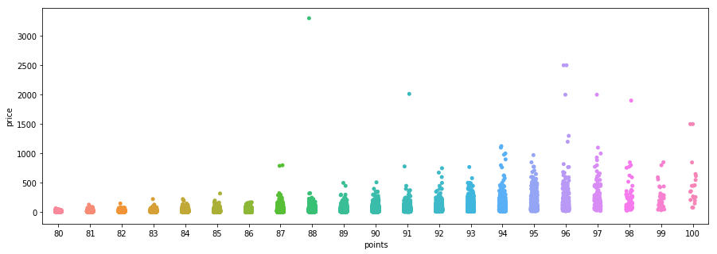

```python
size()
sns.stripplot(x='points', y='price', data=df);
```

The interesting insight here is that the rating is not necessarily correlated with the price, as we have seen with the outliers. If we check the correlation matrix between points and price, we get a correlation of about 0.41, which is not terrible but clearly not as high as one would expect.

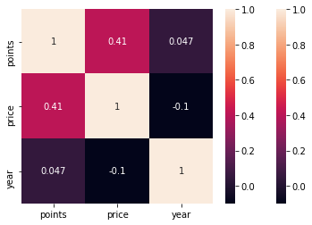

```python
heat = df.corr()
sns.heatmap(heat)
sns.heatmap(heat,annot=True)
plt.show()
```

This following function will be used to compute outliers across the numerical variables in the dataset. I have chosen to identify points beyond 3 standard deviations as outliers.

```python
def Outliers(data):

    # calculating mean and std of the array
    data_mean, data_std = np.mean(data), np.std(data)

    # seting the cut line to both higher and lower values
    cut = data_std * 3

    #Calculating the higher and lower cut values
    lower, upper = data_mean - cut, data_mean + cut

    # creating an array of lower, higher and total outlier values
    outliers_lower = [x for x in data if x < lower]
    outliers_higher = [x for x in data if x > upper]
    outliers_total = [x for x in data if x < lower or x > upper]

    # array without outlier values
    outliers_removed = [x for x in data if x > lower and x < upper]

    print('Outliers lower bound: %d' % lower)
    print('Outliers upped boud: %d' % upper)
    print('Identified lowest outliers: %d' % len(outliers_lower)) # printing total number of values in lower cut of outliers
    print('Identified upper outliers: %d' % len(outliers_higher)) # printing total number of values in higher cut of outliers
    print('Identified outliers: %d' % len(outliers_total)) # printing total number of values outliers of both sides
    print('Non-outlier observations: %d' % len(outliers_removed)) # printing total number of non outlier values
    print("Total percentual of Outliers: ", round((len(outliers_total) / len(outliers_removed) )*100, 4)) # Percentual of outliers in points

    return
```

```python
Outliers(df['points'])
```

```
Outliers lower bound: 79
Outliers upped boud: 97
Identified lowest outliers: 0
Identified upper outliers: 129
Identified outliers: 129
Non-outlier observations: 119859
Total percentual of Outliers:  0.1076
```

**Exploration of prices**

What are some of the descriptive characteristics of the wine prices?

```python
df['price'] = df['price'].round(2)
```

```python
df['price'].describe()
```

```
count    119988.000000
mean         35.795044
std          40.796127
min           4.000000
25%          18.000000
50%          26.000000
75%          45.000000
max        3300.000000
Name: price, dtype: float64
```

The cheapest wine is as cheap as \$4, yet the most expensive one reaches \\$3300!

From the quartiles outputs, we should expect to see a rightly skewed distribution. For the sake of clarity, I will only plot the distribution of prices less than \$200.

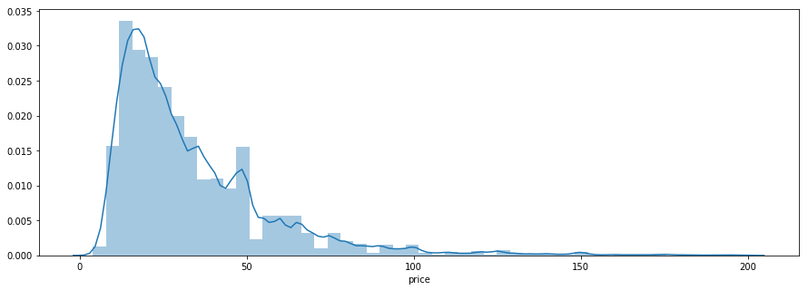

```python
size()
sns.distplot(df[df['price']<200]['price']);
```

```python
Outliers(df['price'])
```

```
Outliers lower bound: -86
Outliers upped boud: 158
Identified lowest outliers: 0
Identified upper outliers: 1140
Identified outliers: 1140
Non-outlier observations: 118848
Total percentual of Outliers:  0.9592
```

```python
cheap = df[df['price']==4]
expensive = df[df['price']==3300]

print('There are %d cheap wines with a price of $4' % cheap['price'].value_counts())

print('There is %d expensive wines with a price of $3300' % expensive['price'].value_counts())

print('The mean price for the cheap wines is $%d' % cheap['points'].mean())

print('The price for the most expensive wine is $%d' % expensive['points'].mean()) #Although there is only one
```

```
There are 11 cheap wines with a price of $4
There is 1 expensive wines with a price of $3300
The mean price for the cheap wines is $84
The price for the most expensive wine is $88
```

For a price difference of 3296$, the most expensive does not even get 4 full points more. Thus, are the wines really not that different or are wines ranked based on other characteristics? If so, why would the website propose all wines for review for users indepedently of their price? Perhaps a ranking system based on sub-characteristics, such as the price of the bottle, would be more meaningful.

**Year Exploration**

```python
df['year'].describe()
```

```
count    119988.000000
mean       2010.599243
std           3.657516
min        1904.000000
25%        2009.000000
50%        2011.000000
75%        2013.000000
max        2017.000000
Name: year, dtype: float64
```

The remaining wines with a year before 1974 are mainly portos or special cave wines, which is fine, since those can be conserved for a long time period.

```python
bins = pd.cut(df['year'],10)
```

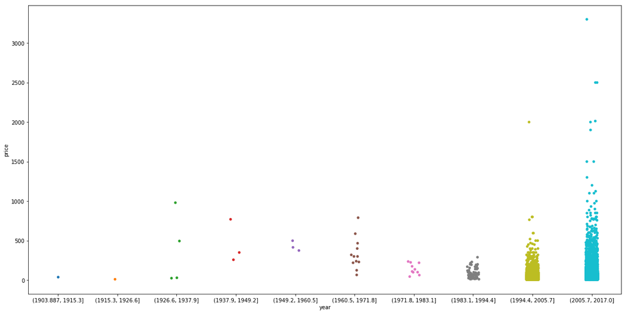

```python
size(20,10)
sns.stripplot(x=bins, y='price', data=df);
```

Very interesting. Contrary to the popular misconception that wines get better as time passes, thus potentially more expensive, this plot reveals that the most expensive wines are less than 12 years old (at the time the data was collected).

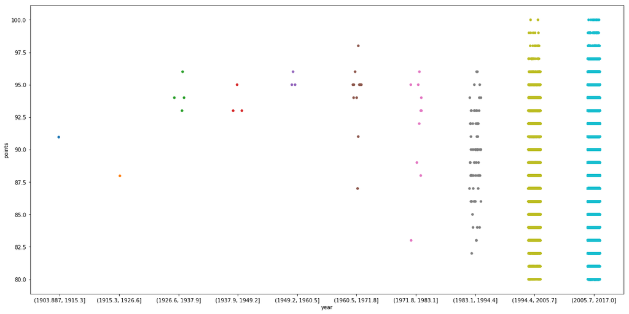

```python
size(20,10)
sns.stripplot(x=bins, y='points', data=df);
```

The same chart to visualize the points received against the year shows that in general, wines older than 1983 seldom gets rated below 90. On the other hand, wines from 1994 and on cover a wide variety of points, from 80 to 100.

## 4. Business Questions

### 4.1. What are the most expensive wines?

```python
# How many wines are worth more than $1000?

len(df[df['price']>1000])
```

```
14
```

```python
# Precise dataframe of those wines

expensive_wines = df[df['price']>1000]
expensive_wines.head()
```

| index | country | description | designation | points | price | year | province | region_1 | region_2 | taster_name | taster_twitter_handle | title | variety | winery |
| --- | --- | --- | --- | --- | --- | --- | --- | --- | --- | --- | --- | --- | --- | --- |
| 1558 | France | A massive wine for Margaux, packed with tannin... | None | 98 | 1900.0 | 2009 | Bordeaux | Margaux | None | Roger Voss | @vossroger | Château Margaux 2009 Margaux | Bordeaux-style Red Blend | Château Margaux |
| 1566 | France | Such a generous and ripe wine, with a dark cor... | None | 97 | 1100.0 | 2009 | Bordeaux | Pessac-Léognan | None | Roger Voss | @vossroger | Château La Mission Haut-Brion 2009 Pessac-Léo... | Bordeaux-style Red Blend | Château La Mission Haut-Brion |
| 1571 | France | Solid, very structured, packed with dense and ... | None | 96 | 1200.0 | 2009 | Bordeaux | Pessac-Léognan | None | Roger Voss | @vossroger | Château Haut-Brion 2009 Pessac-Léognan | Bordeaux-style Red Blend | Château Haut-Brion |
| 1575 | France | The purest Cabernet Sauvignon fruit, with dark... | None | 96 | 1300.0 | 2009 | Bordeaux | Pauillac | None | Roger Voss | @vossroger | Château Mouton Rothschild 2009 Pauillac | Bordeaux-style Red Blend | Château Mouton Rothschild |
| 15840 | France | The wine is a velvet glove in an iron fist. Th... | None | 96 | 2500.0 | 2014 | Bordeaux | Pomerol | None | Roger Voss | @vossroger | Château Pétrus 2014 Pomerol | Bordeaux-style Red Blend | Château Pétrus |

```python
# Which countries are most present in this list?

expensive_wines['country'].describe()
```

```
count         14
unique         3
top       France
freq          12
Name: country, dtype: object
```

```python
expensive_wines.describe()
```

|  | points | price | year |
| --- | --- | --- | --- |
| count | 14.000000 | 14.000000 | 14.000000 |
| mean | 95.642857 | 1788.428571 | 2010.071429 |
| std | 3.201133 | 655.692202 | 2.615465 |
| min | 88.000000 | 1100.000000 | 2005.000000 |
| 25% | 94.500000 | 1225.000000 | 2009.000000 |
| 50% | 96.000000 | 1700.000000 | 2010.000000 |
| 75% | 97.000000 | 2009.750000 | 2012.500000 |
| max | 100.000000 | 3300.000000 | 2014.000000 |

```python
expensive_wines.sort_values('price',ascending=False).head(5)
```

| index | country | description | designation | points | price | year | province | region_1 | region_2 | taster_name | taster_twitter_handle | title | variety | winery |
| --- | --- | --- | --- | --- | --- | --- | --- | --- | --- | --- | --- | --- | --- | --- |
| 80290 | France | This ripe wine shows plenty of blackberry frui... | None | 88 | 3300.0 | 2013 | Bordeaux | Médoc | None | Roger Voss | @vossroger | Château les Ormes Sorbet 2013 Médoc | Bordeaux-style Red Blend | Château les Ormes Sorbet |
| 15840 | France | The wine is a velvet glove in an iron fist. Th... | None | 96 | 2500.0 | 2014 | Bordeaux | Pomerol | None | Roger Voss | @vossroger | Château Pétrus 2014 Pomerol | Bordeaux-style Red Blend | Château Pétrus |
| 98380 | France | A superb wine from a great year, this is power... | None | 96 | 2500.0 | 2010 | Burgundy | La Romanée | None | Roger Voss | @vossroger | Domaine du Comte Liger-Belair 2010 La Romanée | Pinot Noir | Domaine du Comte Liger-Belair |
| 120391 | US | The nose on this single-vineyard wine from a s... | Roger Rose Vineyard | 91 | 2013.0 | 2013 | California | Arroyo Seco | Central Coast | Matt Kettmann | @mattkettmann | Blair 2013 Roger Rose Vineyard Chardonnay (Arr... | Chardonnay | Blair |
| 65352 | France | This extravagantly perfumed wine has great jui... | None | 97 | 2000.0 | 2011 | Bordeaux | Pomerol | None | Roger Voss | @vossroger | Château Pétrus 2011 Pomerol | Bordeaux-style Red Blend | Château Pétrus |

4 out of 5 top priced wines are French, and all French wines have been tested by Roger Voss. The remaining wine, a California wine tasted by Matt Kettman, ranks 4th at a price point of $2013.

France is the country with the vast majority (85\%). Surprisingly, none of the wines are older than 2005, which is corresponds to 12 years of age from the data the data was gathered.

### 4.2. Which countries produce the most wine in this dataset?

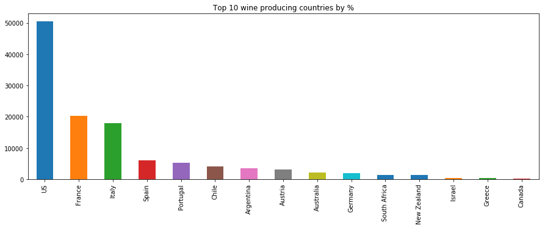

```python
size()
(df['country'].value_counts().head(15)).plot.bar(title='Top 10 wine producing countries by %');
```

The US produces more than 1/4 of wines reviewed in this magazine. Considering that this is a US based website, this makes sense, and the following wines are French, Italian and Spanish, which also have a large market share here in the US.

### 4.3. What does the distribution of price and points look like by country?

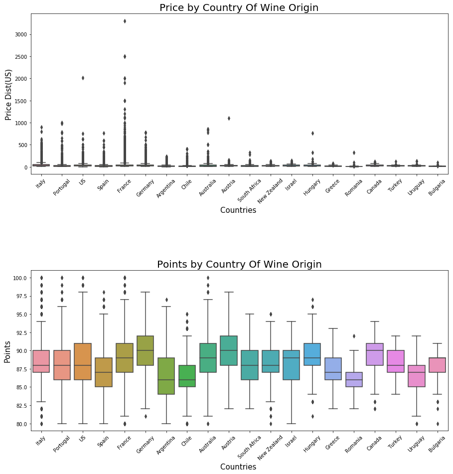

```python
size(15,15)

country=df.country.value_counts()[:20]

plt.subplot(2,1,1)
g = sns.boxplot(x='country', y='price',
                  data=df.loc[(df.country.isin(country.index.values))])
g.set_title("Price by Country Of Wine Origin", fontsize=20)
g.set_xlabel("Countries ", fontsize=15)
g.set_ylabel("Price Dist(US)", fontsize=15)
g.set_xticklabels(g.get_xticklabels(),rotation=45)

plt.subplot(2,1,2)
g1 = sns.boxplot(x='country', y='points',
                   data=df[df.country.isin(country.index.values)])
g1.set_title("Points by Country Of Wine Origin", fontsize=20)
g1.set_xlabel("Countries ", fontsize=15)
g1.set_ylabel("Points", fontsize=15)
g1.set_xticklabels(g1.get_xticklabels(),rotation=45)

plt.subplots_adjust(hspace = 0.6,top = 0.9)

plt.show()
```

*Price by Country*: This graph shows that France has no competition when it comes to price. They price their wines way higher than other countries. Besides a wine from the US priced at around \$2000, France owns the totality of other wines priced above \\$1500.

In the middle tier, we have Italy, Portugal, US, Spain, Germany and to a lower extent Australia. These countries consistently price their wines between \$4 and \\$1000.

Finall, the distribution of the low-tier markets such as New-Zealand, Israel, Greece, Romania, Canada, Turkey, Uruguay and Bulgaria. Those countries seem to price their wines relatively cheaply, with few, if any, wines more expensive than roughly \$250.

### 4.4. For regular consumers, how does the distribution of points/price look like by country?

Regular consumers are not interested in knowing how high the price of a bottle can go. Instead, what matters to them is the price in comparison to the ratings received. For example, someone travelling to a country may want to know how the wines there are rated, and whether he should expect to pay a substantial amount of money for a wine he would be able to get somewhere else cheaper, of the same quality.

I will reproduce the same visualization as before only isolating prices below \$200 this time.

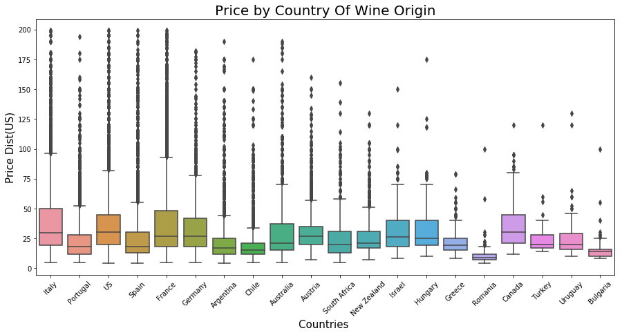

```python
size(15,15)

plt.subplot(2,1,1)
g = sns.boxplot(x='country', y='price',
                  data=df.loc[(df.country.isin(country.index.values))
                              & (df.price < 200)])
g.set_title("Price by Country Of Wine Origin", fontsize=20)
g.set_xlabel("Countries ", fontsize=15)
g.set_ylabel("Price Dist(US)", fontsize=15)
g.set_xticklabels(g.get_xticklabels(),rotation=45)

plt.show()
```

The picture is much clearer here. We can see that all countries have quartiles in values lower than 100 - meaning that most of their wines are affordable, and that there is a large choice for the consumer. In terms of median prices though, the most expensive countries turn out to be Canada and the United State, which is surprising considering that these two countries are not known for necessarily having the best wines. On the other hand, the distribution for France and Italy shows that there is a large choice for a median price of about \$26, which is relatively cheap.

### 4.5. Which provinces' names are the most valuable?

Sometimes more than the country itself, the province of origin for the wines can be an indicator of the quality of the wine, regardless of other factors.

For this section, I will plot 3 graphs depicting all characteristics of the region, and analyze them one by one

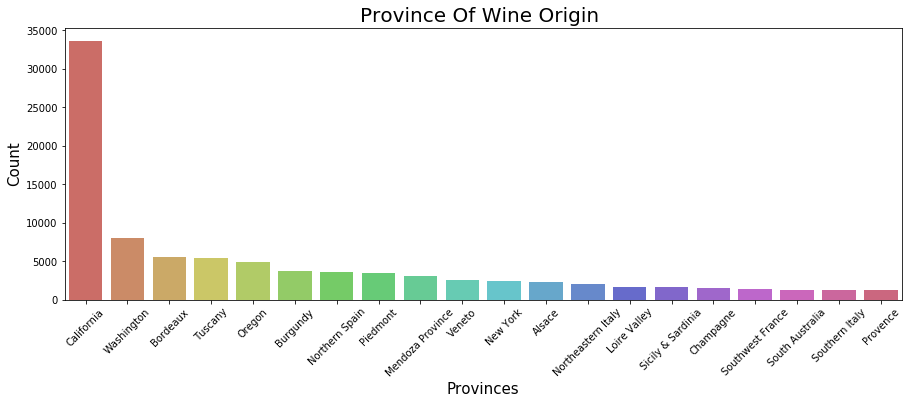

```python
size(15,5)

provinces = df['province'].value_counts()[:20]

g = sns.countplot(x='province',
                  data=df.loc[(df.province.isin(provinces.index.values))],
                 palette='hls', order = df['province'].value_counts()[:20].index)
g.set_title("Province Of Wine Origin ", fontsize=20)
g.set_xlabel("Provinces", fontsize=15)
g.set_ylabel("Count", fontsize=15)
g.set_xticklabels(g.get_xticklabels(),rotation=45)

plt.show()
```

Unsurprisingly, California is the 'province' that produces the most wines. However, it is important to note that California alone is roughly the size of France or Italy, which is important to understand to put its big output in perspective.

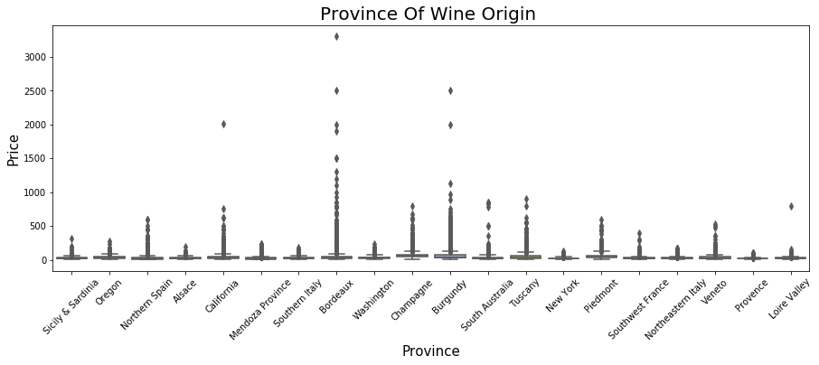

```python
size(15,5)

g1 = sns.boxplot(y='price', x='province',
                  data=df.loc[(df.province.isin(provinces.index.values))],
                 palette='Set2')
g1.set_title("Province Of Wine Origin ", fontsize=20)
g1.set_xlabel("Province", fontsize=15)
g1.set_ylabel("Price", fontsize=15)
g1.set_xticklabels(g1.get_xticklabels(),rotation=45)

plt.show();
```

The picture depicted by this chart is a lot different. Size does not matter after all, as we see that the provinces of Bordeaux and Burgundy boast the most expensive wines despite their relatively smaller output, as seen in the chart above. But how do the provinces hold up against ratings?

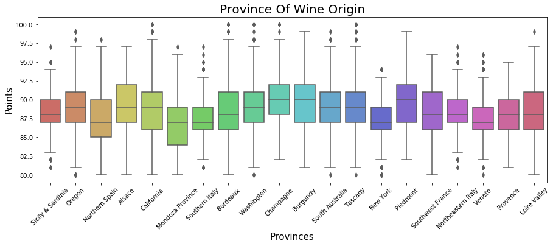

```python
size(15,5)

g2 = sns.boxplot(y='points', x='province',
                  data=df.loc[(df.province.isin(provinces.index.values))],
                 palette='hls')
g2.set_title("Province Of Wine Origin", fontsize=20)
g2.set_xlabel("Provinces", fontsize=15)
g2.set_ylabel("Points", fontsize=15)
g2.set_xticklabels(g2.get_xticklabels(),rotation=45)

plt.show()
```

Bordeaux seems to slack a little, while still boasting the highest possible ratings for some wines, its median rating is only of about 88. The highest rated provinces are the French Champagne and Burgundy and the Italian Piedmont.

Thus, the most valuable names of provinces are Champagne, Burgundy, Piedmont, Bordeaux and to a lesser extent California.

### 4.5 What varieties are the most popular / highly rated?

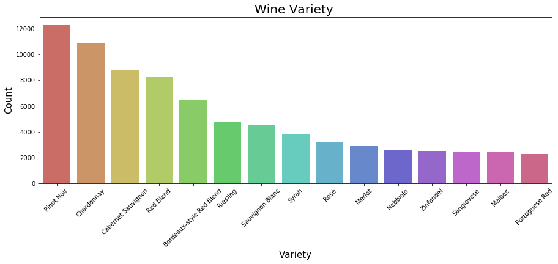

```python
size(15,5)

varieties = df['variety'].value_counts()[:15]

g = sns.countplot(x='variety',
                  data=df.loc[(df.variety.isin(varieties.index.values))],
                 palette='hls', order= df['variety'].value_counts()[:15].index)
g.set_title("Wine Variety ", fontsize=20)
g.set_xlabel("Variety", fontsize=15)
g.set_ylabel("Count", fontsize=15)
g.set_xticklabels(g.get_xticklabels(),rotation=45)

plt.show()
```

Pinot Noir and Chardonnay are the most sought after wine varieties, followed by Cabernet Sauvignon and a miscellaneous 'red blend' category.

In other words, red wines are the most popular (Pinot Noir, Cabernet Sauvignon and the 'red blend' and bordeaux-style red blend), followed by the Chardonnay variety.

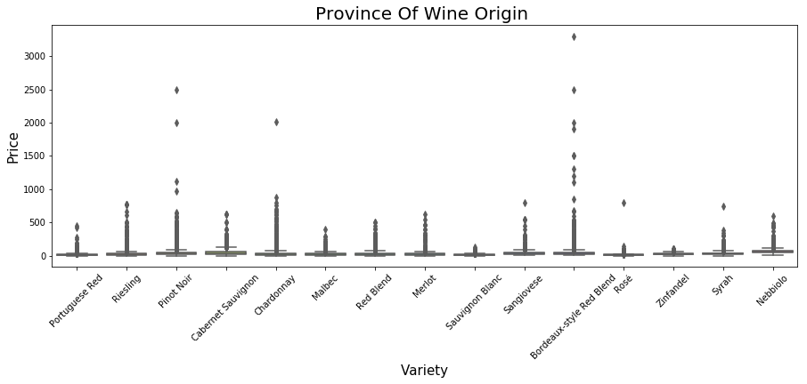

```python
size(15,5)

g1 = sns.boxplot(y='price', x='variety',
                  data=df.loc[(df.variety.isin(varieties.index.values))],
                 palette='hls')
g1.set_title("Province Of Wine Origin ", fontsize=20)
g1.set_xlabel("Variety", fontsize=15)
g1.set_ylabel("Price", fontsize=15)
g1.set_xticklabels(g1.get_xticklabels(),rotation=45)

plt.show()
```

We see clearly that the most expensive varities are the bordeaux style red blend, the pinot noir and the chardonnay - confirming the analysis from the first chart above.

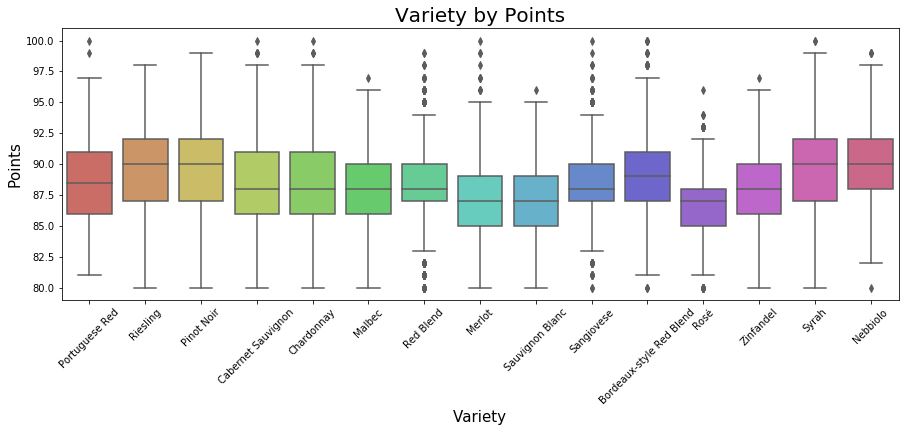

```python
size(15,5)

g2 = sns.boxplot(y='points', x='variety',
                  data=df.loc[(df.variety.isin(varieties.index.values))],
                 palette='hls')
g2.set_title("Variety by Points", fontsize=20)
g2.set_xlabel("Variety", fontsize=15)
g2.set_ylabel("Points", fontsize=15)
g2.set_xticklabels(g2.get_xticklabels(),rotation=45)

plt.show()
```

Another interesting insight - the highest rated varieties are the riesling, the pinot noir, the syrah and the nebbiolo, with a median rating of 90. The cabernet sauvignon falls behind, at a median rating of about 88. The lowest rated wine variety is the rose, which is a cross between red and white, mostly popular in souther european countries during the summer.

### 4.6 Who are the most influential tasters?

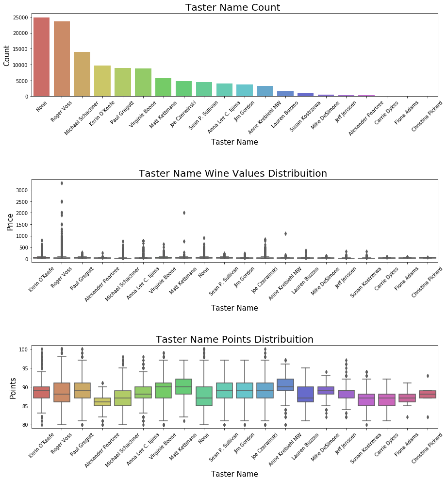

```python
size(15,5)

plt.subplot(3,1,1)
g = sns.countplot(x='taster_name', data=df, palette='hls',order=df['taster_name'].value_counts().index)
g.set_title("Taster Name Count ", fontsize=20)
g.set_xlabel("Taster Name", fontsize=15)
g.set_ylabel("Count", fontsize=15)
g.set_xticklabels(g.get_xticklabels(),rotation=45)

plt.subplot(3,1,2)
g1 = sns.boxplot(y='price', x='taster_name', data=df,
                 palette='hls')
g1.set_title("Taster Name Wine Values Distribuition ", fontsize=20)
g1.set_xlabel("Taster Name", fontsize=15)
g1.set_ylabel("Price", fontsize=15)
g1.set_xticklabels(g1.get_xticklabels(),rotation=45)

plt.subplot(3,1,3)
g2 = sns.boxplot(y='points', x='taster_name',
                  data=df, palette='hls')
g2.set_title("Taster Name Points Distribuition", fontsize=20)
g2.set_xlabel("Taster Name", fontsize=15)
g2.set_ylabel("Points", fontsize=15)
g2.set_xticklabels(g2.get_xticklabels(),rotation=45)

plt.subplots_adjust(hspace = 1,top = 2.5)

plt.show()
```

Roger Voss is the most common reviewer, with close to 23,000 reviews. Since the data does not provide the date at which the review was collected, I assume that Roger Voss may be the most senior wine reviewer given his incredible contribution. Furthermore, he is also in charge of reviewing the most expensive wines, as we can see from the second chart.

According to the source, Roger Voss is an reviewer covering France and Portugal. With more than 6 books written on wine and pairing it with food, as well as being the previous national correspondent on wine for the London Daily Telegraph, Voss is an eminent expert.

## 5. Understanding the wine descriptions

### 5.1. Length of the review

The common idea is that the fancier the description, the richer the wine, thus the better it is. Let's check if this theory holds.

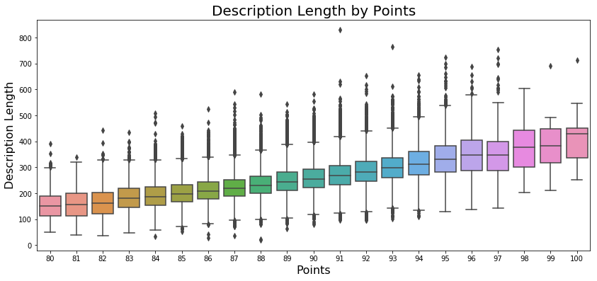

```python
df = df.assign(desc_len = df['description'].apply(len))

plt.figure(figsize=(14,6))
g = sns.boxplot(x='points', y='desc_len', data=df)
g.set_title('Description Length by Points', fontsize=20)
g.set_ylabel('Description Length', fontsize = 16) # Y label
g.set_xlabel('Points', fontsize = 16) # X label
plt.show()
```

What we see here is that as the ranking increases, so does the description length. The median description length for a wine rated at 80 is approximately 150 characters, whereas the description length for a wine ranked 100 has a median of about 400 characters.

What does the correlation look like between the description length and the points/price?

```python
df['desc_len'] = pd.to_numeric(df['desc_len'])
df.corr()
```

|  | points | price | year | desc_len |
| --- | --- | --- | --- | --- |
| points | 1.000000 | 0.407885 | 0.047229 | 0.562235 |
| price | 0.407885 | 1.000000 | -0.099850 | 0.243648 |
| year | 0.047229 | -0.099850 | 1.000000 | -0.077579 |
| desc_len | 0.562235 | 0.243648 | -0.077579 | 1.000000 |

From the correlation table above, the description length seems to be fairly correlated with the points awarded (0.56). However, the correlation with the price is rather weak, only 0.24, meaning that the price, once again, is not a good indicator of the quality of the wine.

### 5.2. Word Cloud

To get a better understanding of what composes the review, a word cloud can be a fun and interactive way to visualize what is going on in the description.

I will create 3 word clouds for the top 3 countries, so we can visualize the differences in descriptions across the countries.

```python
df.country.value_counts().head(3)

# US, France, Italy
```

```
US        50457
France    20353
Italy     17940
Name: country, dtype: int64
```

```python
Italy = df[df['country']=='Italy']
France = df[df['country']=='France']
US = df[df['country']=='US']
```

```python
from wordcloud import WordCloud, STOPWORDS

# Function to call on the word cloud on different countries

def wordcloud(data=df):

    stopwords = set(STOPWORDS)
    stopwords.add('full')
    stopwords.add('now')
    stopwords.add('drink')

    wordcloud = WordCloud(
        background_color='white',
        stopwords=stopwords,
        max_words=1200,
        max_font_size=300,
        width=1500, height=1000,
        random_state=24,
        ).generate(" ".join(data['description'].astype(str)))

    print(wordcloud)
    fig = plt.figure(figsize = (12,14))
    plt.imshow(wordcloud)
    plt.title("Word Cloud - DESCRIPTION" ,fontsize=25)
    plt.axis('off')
    plt.show();
```

```
<wordcloud.wordcloud.WordCloud object at 0x00000294A43EAF98>
```

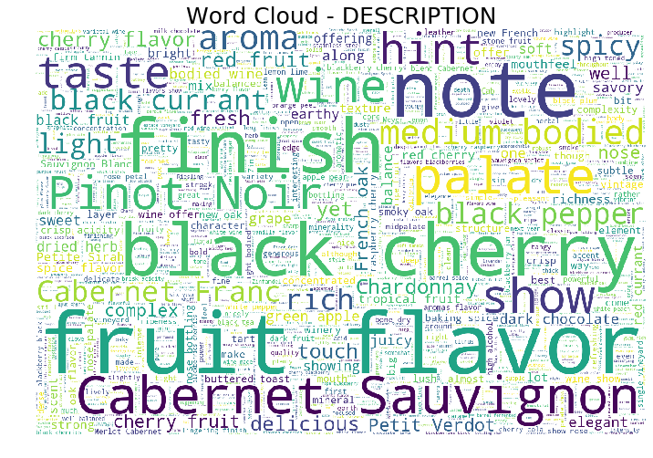

```python
wordcloud(US)
```

```
<wordcloud.wordcloud.WordCloud object at 0x00000294AAB01978>
```

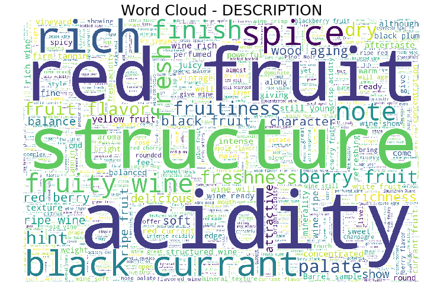

```python
wordcloud(France)
```

```
<wordcloud.wordcloud.WordCloud object at 0x00000294A47009E8>
```

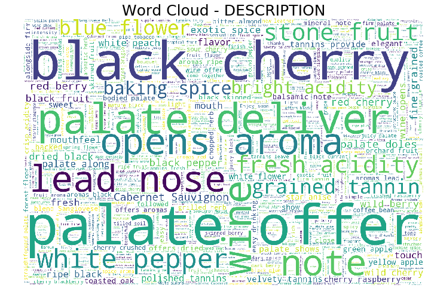

```python
wordcloud(Italy)
```

The differences between countries are notable. The US tend to have have more medium bodied wines, whereas France seem to have more acidic wines. Italy seems to have more subtle wines, with recurring words such as opens aroma and lead the nose. Overall, all wines have flavors of red fruits, with the addition of spices, which differ depending on the country.

```
<wordcloud.wordcloud.WordCloud object at 0x00000294AAFBBD30>
```

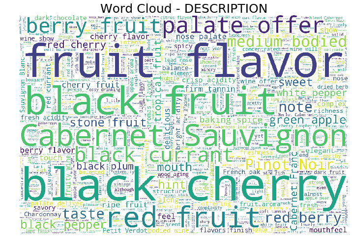

```python
# For the entire dataset

wordcloud()
```

As we have seen, pinot noir and cabernet sauvignon varieties are the most common. To describe these red wines, the most commonly used words relate to fruit and plants, while another cluster of words relate to the tastebuds.

## 6. Conclusion

Our data exploration and visualization led to some great insights. We found that most expensive wines are rarely the oldest, and that the Bordeaux province, despite its great reputation, does not hold up quite as well in terms of overall ratings compared to other wine producing provinces. We found that some countries seem to specialize in certain niche markets - Austria does not produce many wines, but the ones it produces are ranked better without necessarily being more expensive. Romania produces cheap wines who rank on the lower end in terms of ratings. France produces some of the most expensive wines in the world. We also found that red wine is the most common blend reviewed in the dataset. Finally, we learned about Roger Voss, an eminent wine expert, worth following on Twitter for his insighful and objective reviews.

From the source wesbite, here is how the wines are reviewed:

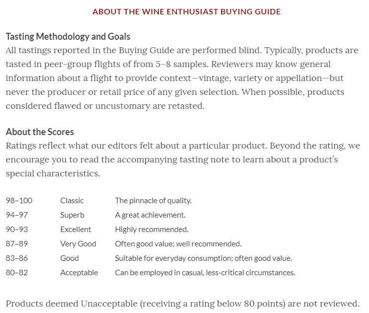

As we have infered from the beginning, the reviews happen blind, with perhaps some context about the wine. However, the price is never available to the reviewer in order not to bias him. Thus the somewhat OK correlation of 0.41.

Which raises the question - if an eminent oenologist cannot make the difference between a highly priced wine and a cheaper wine, assigning to both wine the same ratings, why is there such a difference in the prices of wines?

We assume that there must be external factors dictating the price of a bottle, perhaps it is a very limited production, or the vineyard has been destroyed by fire, or maybe the price to harvest the grapes. It is easy to imagine that a wine for which the grapes are costly to harvest, thus producing bottles in lower quantities, will have a higher price for a similar quality compared to a wine that is easier to produce.

Similarly, the packaging and the distribution strategy can influence the price of a wine, i.e. if a wine is widely distributed with a somewhat unsophisticated packaging, the price may be lower than if the same exact wine was only available at specialty stores, with a fancier packaging.

## 7. References

Dataset: https://www.kaggle.com/zynicide/wine-reviews

Website from which the data was scrapped: https://www.winemag.com/?s=&drink_type=wine

Roger Voss: https://www.winemag.com/taster/roger-voss/

How to determine the price of a wine: https://www.famigliacecchi.it/en/news/which-factors-determine-the-price-of-wine/190

How to read a wine label: https://napavintners.com/wines/how_to_read_a_wine_label.asp